# 002_ExploratoryAnalysis_DistributionTrendsAssociation

## Exploratory Analysis of dataset derived from Road Accidents STATS19 dataset

Approach: 1) Wrangled data for analysis – Merged datasets, removed redundant/repeated variables, imputed with mean/median/mode, transformed categorical variables to numeric data, converted to tall data format 2) Assessed distribution of data – Bar chart, line graphs, scatter plots, Q-Q plots 3) Observed trends in data – Line graphs, histogram 4) Examined relationship between variables – Correlation matrix, Test of independence with ANOVA

#### Load packages

```python
import csv
import os
import numpy as np
import pandas as pd
import matplotlib
import matplotlib.pyplot as plt
from pandas import ExcelWriter
from pandas import ExcelFile
from sklearn.preprocessing import LabelEncoder
import warnings
import pygeohash as pgh
from sklearn.cluster import KMeans
import matplotlib.cm as cm
from geopy.distance import great_circle
from geopy.distance import vincenty
from datetime import datetime
import seaborn as sns
from bokeh.plotting import figure, show
from bokeh.io import output_notebook
import scipy.stats as stats
warnings.filterwarnings('ignore')
%matplotlib inline
get_ipython().magic('matplotlib inline')
matplotlib.rcParams.update({'font.size': 12})
matplotlib.rc('xtick', labelsize=8)
matplotlib.rc('ytick', labelsize=8)
np.random.seed(10)
%load_ext rpy2.ipython
output_notebook()
```

#### Environment setting

```python
startTime = datetime.now()
wd = "C://MEJ//Data//"
os.chdir(wd)
del wd
```

#### Load data

```python
csvData = pd.read_csv("Exploratory2005_2015.csv")
print(list(csvData.columns))
```

```
['Unnamed: 0', 'Vehicle_Reference', 'Total Casualities', 'Fatal', 'Serious', 'Slight', 'Pedestrian_Count', 'Vehicle_Type', 'Towing_and_Articulation', 'Vehicle_Manoeuvre', 'Vehicle_Location-Restricted_Lane', 'Junction_Location', 'Skidding_and_Overturning', 'Hit_Object_in_Carriageway', 'Vehicle_Leavin…
```

NOTE: Not all variables are included for analysis in this notebook

### Data distribution

```python
#sns.pairplot(csvData)
#pd.scatter_matrix(csvData, alpha = 0.3, figsize = (20,20), diagonal = 'kde')
```

#### Normality test with Q-Q plot

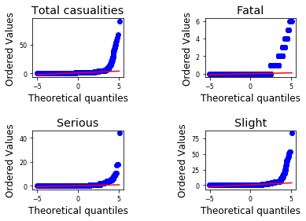

```python
fig = plt.figure()
ax = fig.add_subplot(221)
stats.probplot(csvData['Total Casualities'], dist="norm", plot=plt)
ax.set_title("Total casualities")
ax = fig.add_subplot(222)
stats.probplot(csvData['Fatal'], dist="norm", plot=plt)
ax.set_title("Fatal")
ax = fig.add_subplot(223)
stats.probplot(csvData['Serious'], dist="norm", plot=plt)
ax.set_title("Serious")
ax = fig.add_subplot(224)
stats.probplot(csvData['Slight'], dist="norm", plot=plt)
ax.set_title("Slight")
plt.subplots_adjust(left=None, bottom=None, right=None, top=None, wspace=0.9, hspace=0.9)
plt.show()
```

#### Plotting of a single attribute

##### Vehicle related attributes

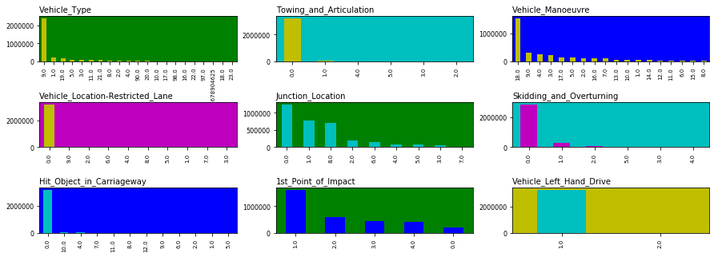

```python
plt.figure(figsize=(15,5))
plt.subplot(331,facecolor='g')
pd.value_counts(csvData['Vehicle_Type']).plot.bar(color='y')#Attribute on x-axis
plt.title('Vehicle_Type',loc='left',fontsize=10)
plt.xticks(fontsize=7)
plt.subplot(332,facecolor='c')
pd.value_counts(csvData['Towing_and_Articulation']).plot.bar(color='y')#Attribute on x-axis
plt.title('Towing_and_Articulation',loc='left',fontsize=10)
plt.xticks(fontsize=7)
plt.subplot(333,facecolor='b')
pd.value_counts(csvData['Vehicle_Manoeuvre']).plot.bar(color='y')#Attribute on x-axis
plt.title('Vehicle_Manoeuvre',loc='left',fontsize=10)
plt.xticks(fontsize=7)
plt.subplot(334,facecolor='m')
pd.value_counts(csvData['Vehicle_Location-Restricted_Lane']).plot.bar(color='y')#Attribute on x-axis
plt.title('Vehicle_Location-Restricted_Lane',loc='left',fontsize=10)
plt.xticks(fontsize=7)
plt.subplot(335,facecolor='g')
pd.value_counts(csvData['Junction_Location']).plot.bar(color='c')#Attribute on x-axis
plt.title('Junction_Location',loc='left',fontsize=10)
plt.xticks(fontsize=7)
plt.subplot(336,facecolor='c')
pd.value_counts(csvData['Skidding_and_Overturning']).plot.bar(color='m')#Attribute on x-axis
plt.title('Skidding_and_Overturning',loc='left',fontsize=10)
plt.xticks(fontsize=7)
plt.subplot(337,facecolor='b')
pd.value_counts(csvData['Hit_Object_in_Carriageway']).plot.bar(color='c')#Attribute on x-axis
plt.title('Hit_Object_in_Carriageway',loc='left',fontsize=10)
plt.xticks(fontsize=7)
plt.subplot(338,facecolor='g')
pd.value_counts(csvData['1st_Point_of_Impact']).plot.bar(color='b')#Attribute on x-axis
plt.title('1st_Point_of_Impact',loc='left',fontsize=10)
plt.xticks(fontsize=7)
plt.subplot(339,facecolor='y')
pd.value_counts(csvData['Vehicle_Left_Hand_Drive']).plot.bar(color='c')#Attribute on x-axis
plt.title('Vehicle_Left_Hand_Drive',loc='left',fontsize=10)
plt.xticks(fontsize=7)
plt.subplots_adjust(left=None, bottom=None, right=None, top=None, wspace=None, hspace=0.9)
plt.show()
```

##### Driver related attributes

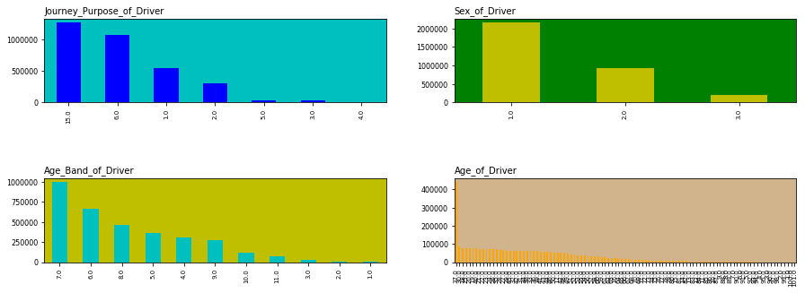

```python
plt.figure(figsize=(15,5))
plt.subplot(221,facecolor='c')
pd.value_counts(csvData['Journey_Purpose_of_Driver']).plot.bar(color='b')#Attribute on x-axis
plt.title('Journey_Purpose_of_Driver',loc='left',fontsize=10)
plt.xticks(fontsize=7)
plt.subplot(222,facecolor='g')
pd.value_counts(csvData['Sex_of_Driver']).plot.bar(color='y')#Attribute on x-axis
plt.title('Sex_of_Driver',loc='left',fontsize=10)
plt.xticks(fontsize=7)
plt.subplot(223,facecolor='y')
pd.value_counts(csvData['Age_Band_of_Driver']).plot.bar(color='c')#Attribute on x-axis
plt.title('Age_Band_of_Driver',loc='left',fontsize=10)
plt.xticks(fontsize=7)
plt.subplot(224,facecolor='tan')
pd.value_counts(csvData['Age_of_Driver']).plot.bar(color='orange')#Attribute on x-axis
plt.title('Age_of_Driver',loc='left',fontsize=10)
plt.xticks(fontsize=7)
plt.subplots_adjust(left=None, bottom=None, right=None, top=None, wspace=None, hspace=0.9)
plt.show()
```

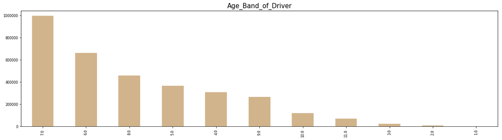

```python
plt.figure(figsize=(20,5))
pd.value_counts(csvData['Age_Band_of_Driver']).plot.bar(color='tan')#Attribute on x-axis
plt.title('Age_Band_of_Driver', fontsize=15)
plt.show()
```

```python
csvData['Sex_of_Driver'].unique()
genderData = csvData.copy(deep=True)
genderData['Sex_of_Driver'] = genderData['Sex_of_Driver'].apply(lambda x: int(x))
genderData['Sex_of_Driver'].unique()
genderData = csvData[csvData['Sex_of_Driver']!=3]
genderData['Sex_of_Driver'].unique()
genderData['Sex_of_Driver'] = genderData['Sex_of_Driver'].apply(lambda x: int(x))
```

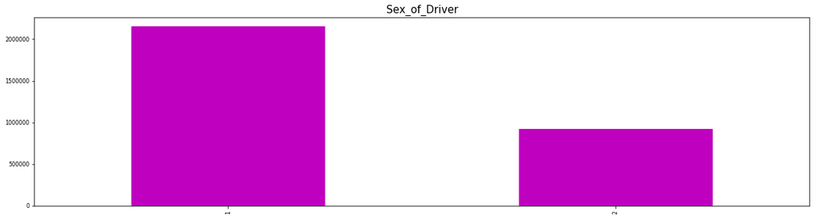

```python
plt.figure(figsize=(20,5))
pd.value_counts(genderData['Sex_of_Driver']).plot.bar(color='m')#Attribute on x-axis
plt.title('Sex_of_Driver', fontsize=15)
plt.show()
```

##### Pedestrian related attributes

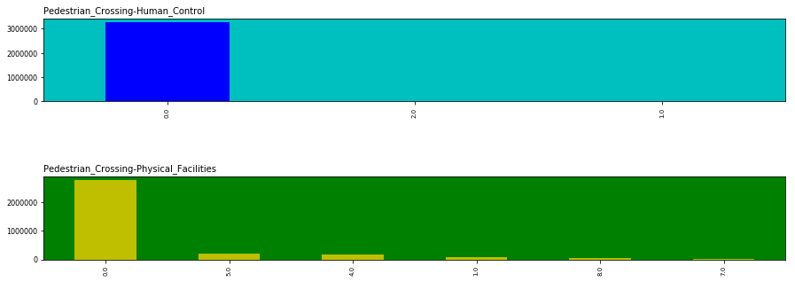

```python
plt.figure(figsize=(15,5))
plt.subplot(211,facecolor='c')
pd.value_counts(csvData['Pedestrian_Crossing-Human_Control']).plot.bar(color='b')#Attribute on x-axis
plt.title('Pedestrian_Crossing-Human_Control',loc='left',fontsize=10)
plt.xticks(fontsize=7)
plt.subplot(212,facecolor='g')
pd.value_counts(csvData['Pedestrian_Crossing-Physical_Facilities']).plot.bar(color='y')#Attribute on x-axis
plt.title('Pedestrian_Crossing-Physical_Facilities',loc='left',fontsize=10)
plt.xticks(fontsize=7)
plt.subplots_adjust(left=None, bottom=None, right=None, top=None, wspace=None, hspace=0.9)
plt.show()
```

##### Road related attributes

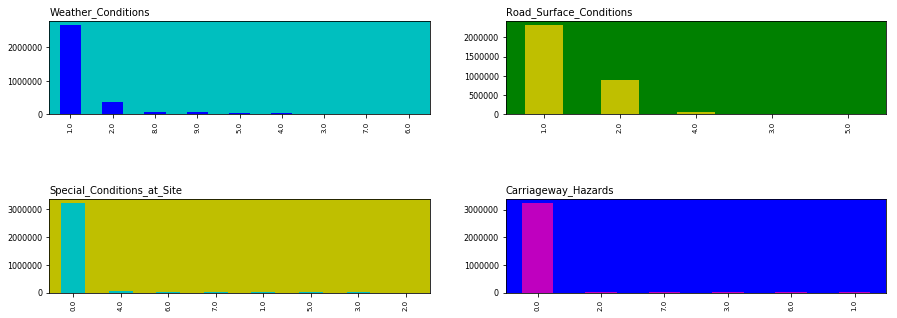

```python
plt.figure(figsize=(15,5))
plt.subplot(221,facecolor='c')
pd.value_counts(csvData['Weather_Conditions']).plot.bar(color='b')#Attribute on x-axis
plt.title('Weather_Conditions',loc='left',fontsize=10)
plt.xticks(fontsize=7)
plt.subplot(222,facecolor='g')
pd.value_counts(csvData['Road_Surface_Conditions']).plot.bar(color='y')#Attribute on x-axis
plt.title('Road_Surface_Conditions',loc='left',fontsize=10)
plt.xticks(fontsize=7)
plt.subplot(223,facecolor='y')
pd.value_counts(csvData['Special_Conditions_at_Site']).plot.bar(color='c')#Attribute on x-axis
plt.title('Special_Conditions_at_Site',loc='left',fontsize=10)
plt.xticks(fontsize=7)
plt.subplot(224,facecolor='b')
pd.value_counts(csvData['Carriageway_Hazards']).plot.bar(color='m')#Attribute on x-axis
plt.title('Carriageway_Hazards',loc='left',fontsize=10)
plt.xticks(fontsize=7)
plt.subplots_adjust(left=None, bottom=None, right=None, top=None, wspace=None, hspace=0.9)
plt.show()
```

##### Accident severity related attributes

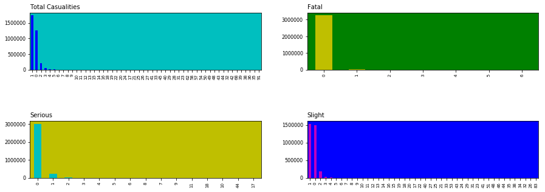

```python
plt.figure(figsize=(15,5))
plt.subplot(221,facecolor='c')
pd.value_counts(csvData['Total Casualities']).plot.bar(color='b')#Attribute on x-axis
plt.title('Total Casualities',loc='left',fontsize=10)
plt.xticks(fontsize=7)
plt.subplot(222,facecolor='g')
pd.value_counts(csvData['Fatal']).plot.bar(color='y')#Attribute on x-axis
plt.title('Fatal',loc='left',fontsize=10)
plt.xticks(fontsize=7)
plt.subplot(223,facecolor='y')
pd.value_counts(csvData['Serious']).plot.bar(color='c')#Attribute on x-axis
plt.title('Serious',loc='left',fontsize=10)
plt.xticks(fontsize=7)
plt.subplot(224,facecolor='b')
pd.value_counts(csvData['Slight']).plot.bar(color='m')#Attribute on x-axis
plt.title('Slight',loc='left',fontsize=10)
plt.xticks(fontsize=7)
plt.subplots_adjust(left=None, bottom=None, right=None, top=None, wspace=None, hspace=0.9)
plt.show()
```

##### Time related attributes

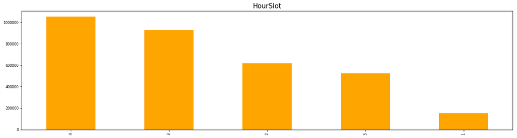

```python
plt.figure(figsize=(20,5))
pd.value_counts(csvData['HourSlot']).plot.bar(color='orange')#Attribute on x-axis
plt.title('HourSlot', fontsize=15)
plt.show()
```

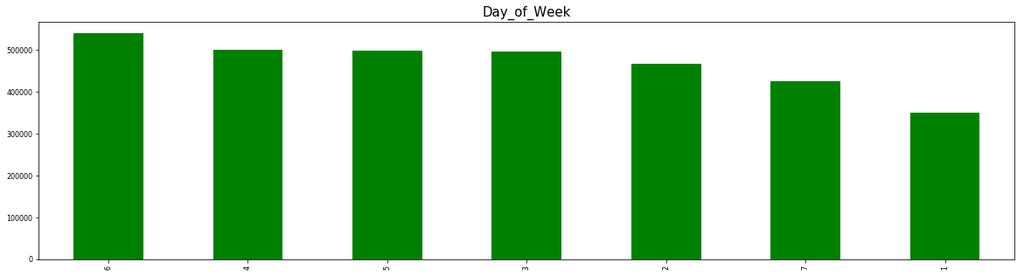

```python
plt.figure(figsize=(20,5))
pd.value_counts(csvData['Day_of_Week']).plot.bar(color='g')#Attribute on x-axis
plt.title('Day_of_Week', fontsize=15)
plt.show()
```

#### Plotting of multiple variables

##### Casualty by Driver Gender (box plot)

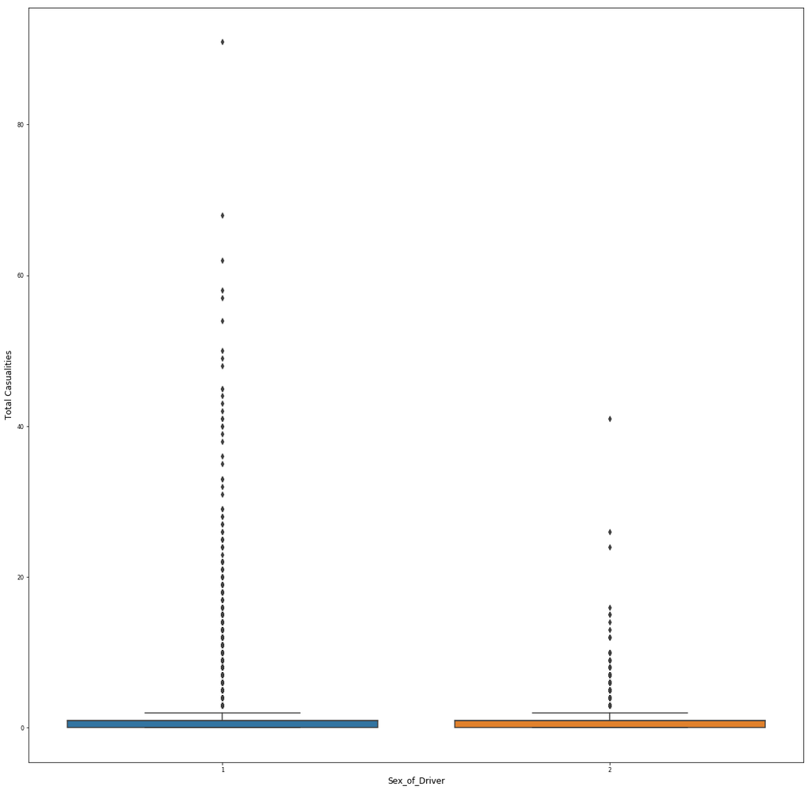

```python
plt.figure(figsize=(20,20))
sns.boxplot( x=genderData["Sex_of_Driver"], y=genderData["Total Casualities"])
del genderData
```

##### Casualty by Vehicle type

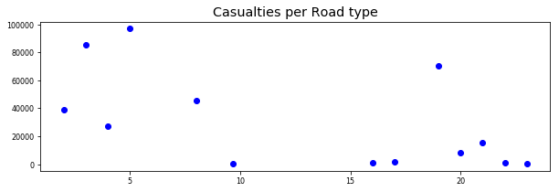

```python
vehicleType = csvData[~csvData['Vehicle_Type'].isin([10,11,18,-1,90,97,98,9,1])]
temp = vehicleType.groupby(['Vehicle_Type']).sum()['Total Casualities']
plt.figure(figsize=(10,3))
plt.grid(False)
plt.scatter(temp.index,temp,c='b')
plt.title('Casualties per Road type')
del vehicleType,temp
```

##### Casualty by Road type

```
Text(0.5,1,'Casualties per Road type')
```

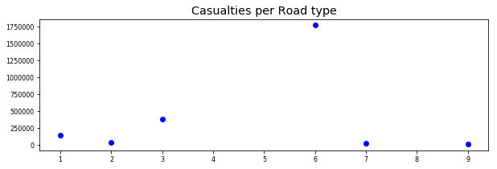

```python
temp = csvData.groupby(['Road_Type']).sum()['Total Casualities']
plt.figure(figsize=(10,3))
plt.grid(False)
plt.scatter(temp.index,temp,c='b')
plt.title('Casualties per Road type')
```

##### Casualty by Light conditions

```
Light_Conditions
1.0    1740520
4.0     477707
5.0      10827
6.0     145903
7.0      26775
Name: Total Casualities, dtype: int64
```

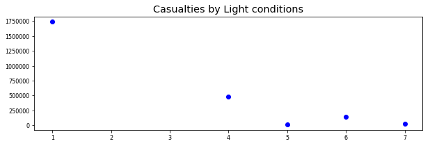

```python
temp = csvData.groupby(['Light_Conditions']).sum()['Total Casualities']
plt.figure(figsize=(10,3))
plt.grid(False)
plt.scatter(temp.index,temp,c='b')
plt.title('Casualties by Light conditions')
temp
```

##### Casualty by Weather conditions

```
Text(0.5,1,'Casualties by Weather conditions')
```

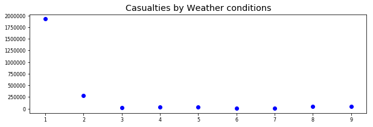

```python
temp = csvData.groupby(['Weather_Conditions']).sum()['Total Casualities']
plt.figure(figsize=(10,3))
plt.grid(False)
plt.scatter(temp.index,temp,c='b')
plt.title('Casualties by Weather conditions')
```

##### Casaulty by Road speed limit

```
Text(0.5,1,'Casualties by Speed limit')
```

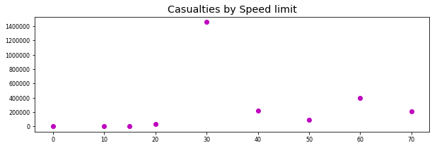

```python
temp = csvData.groupby(['Speed_limit']).sum()['Total Casualities']
plt.figure(figsize=(10,3))
plt.grid(False)
plt.scatter(temp.index,temp,c='m')
plt.title('Casualties by Speed limit')
```

Delving into each category of accident severity - Fatal, Serious, Slight - by Speed limit

```
Text(0.5,1,'Fatalities by Speed limit')
```

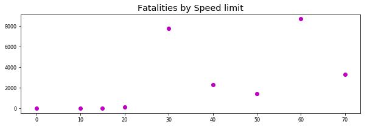

```python
temp = csvData.groupby(['Speed_limit']).sum()['Fatal']
plt.figure(figsize=(10,3))
plt.grid(False)
plt.scatter(temp.index,temp,c='m')
plt.title('Fatalities by Speed limit')
```

```
Text(0.5,1,'Casualties by Speed limit')
```

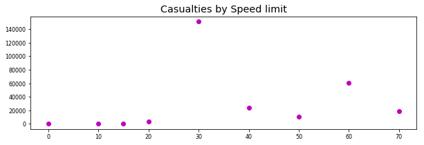

```python
temp = csvData.groupby(['Speed_limit']).sum()['Serious']
plt.figure(figsize=(10,3))
plt.grid(False)
plt.scatter(temp.index,temp,c='m')
plt.title('Casualties by Speed limit')
```

```
Text(0.5,1,'Casualties by Speed limit')
```

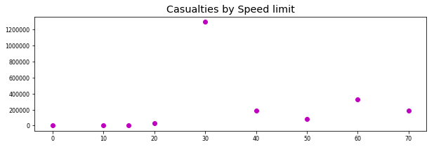

```python
temp = csvData.groupby(['Speed_limit']).sum()['Slight']
plt.figure(figsize=(10,3))
plt.grid(False)
plt.scatter(temp.index,temp,c='m')
plt.title('Casualties by Speed limit')
```

##### Casualty by Journey purpose

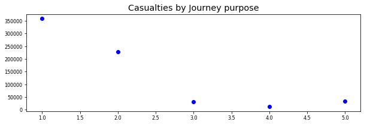

```python
journeyPurpose = csvData[csvData['Journey_Purpose_of_Driver']<6]
temp = journeyPurpose.groupby(['Journey_Purpose_of_Driver']).sum()['Total Casualities']
plt.figure(figsize=(10,3))
plt.grid(False)
plt.scatter(temp.index,temp,c='b')
plt.title('Casualties by Journey purpose')
del temp, journeyPurpose
```

##### Casualty by Month

```
Text(0.5,1,'Casualties by Month')
```

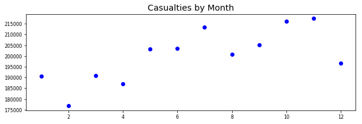

```python
temp = csvData.groupby(['Month']).sum()['Total Casualities']
plt.figure(figsize=(10,3))
plt.grid(False)
plt.scatter(temp.index,temp,c='b')
plt.title('Casualties by Month')
```

##### Casualty by Year

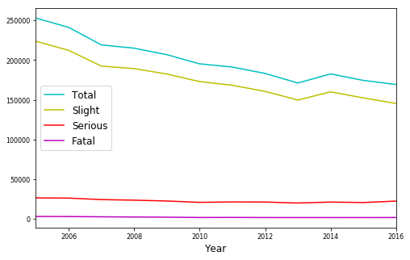

```python
fig, ax = plt.subplots(figsize=(8,5))
csvData.groupby(['Year']).sum()['Total Casualities'].plot(ax=ax,c='c',label='Total')
csvData.groupby(['Year']).sum()['Slight'].plot(ax=ax,c='y',label='Slight')
csvData.groupby(['Year']).sum()['Serious'].plot(ax=ax,c='r',label='Serious')
csvData.groupby(['Year']).sum()['Fatal'].plot(ax=ax,c='m',label='Fatal')
plt.legend()
```

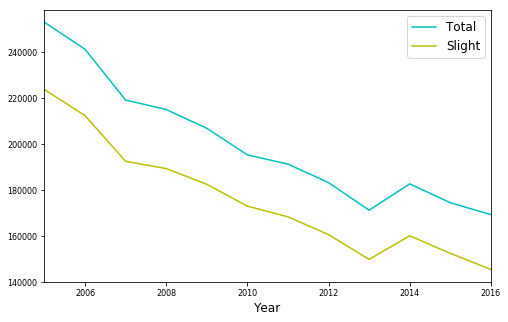

```python
fig, ax = plt.subplots(figsize=(8,5))
csvData.groupby(['Year']).sum()['Total Casualities'].plot(ax=ax,c='c',label='Total')
csvData.groupby(['Year']).sum()['Slight'].plot(ax=ax,c='y',label='Slight')
plt.legend()
```

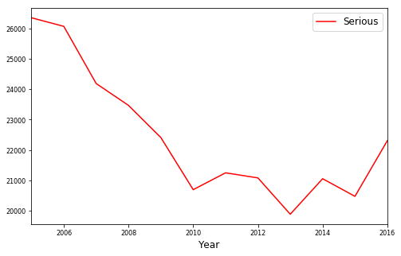

```python
fig, ax = plt.subplots(figsize=(8,5))
csvData.groupby(['Year']).sum()['Serious'].plot(ax=ax,c='r',label='Serious')
plt.legend()
```

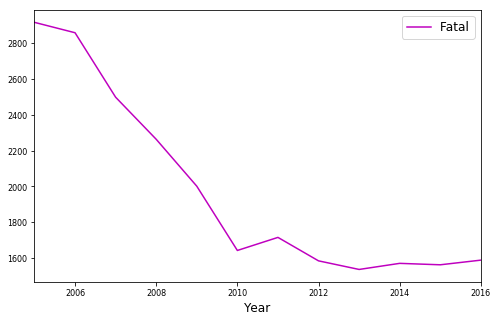

```python
fig, ax = plt.subplots(figsize=(8,5))
csvData.groupby(['Year']).sum()['Fatal'].plot(ax=ax,c='m',label='Fatal')
plt.legend()
```

```python
years = csvData['Year'].unique()
fatal = csvData['Fatal'].groupby(csvData['Year']).sum()
serious = csvData['Serious'].groupby(csvData['Year']).sum()
slight = csvData['Slight'].groupby(csvData['Year']).sum()
total = csvData['Total Casualities'].groupby(csvData['Year']).sum()
print('Years: ', years)
```

```
Years:  [2005 2006 2007 2008 2009 2010 2011 2012 2013 2014 2015 2016]
```

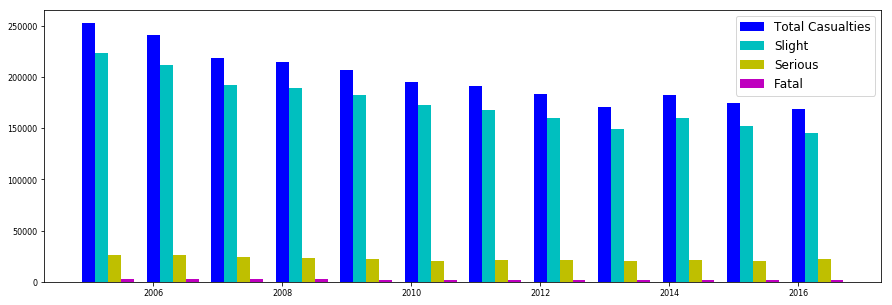

```python
plt.figure(figsize=(15,5))
ax = plt.subplot(111)
ax.bar(years, total,width=0.2,color='b',align='center',label='Total Casualties')
ax.bar(years+0.2, slight,width=0.2,color='c',align='center',label='Slight')
ax.bar(years+0.4, serious,width=0.2,color='y',align='center',label='Serious')
ax.bar(years+0.6, fatal,width=0.2,color='m',align='center',label='Fatal')
#f = ax.plot(years, fatal, 'ms-')
#plt.legend(f)
plt.legend()
plt.show()
```

##### Casualty by day of week

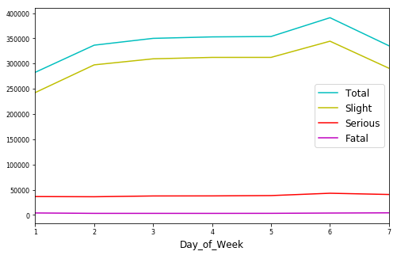

```python
fig, ax = plt.subplots(figsize=(8,5))
csvData.groupby(['Day_of_Week']).sum()['Total Casualities'].plot(ax=ax,c='c',label='Total')
csvData.groupby(['Day_of_Week']).sum()['Slight'].plot(ax=ax,c='y',label='Slight')
csvData.groupby(['Day_of_Week']).sum()['Serious'].plot(ax=ax,c='r',label='Serious')
csvData.groupby(['Day_of_Week']).sum()['Fatal'].plot(ax=ax,c='m',label='Fatal')
plt.legend()
```

Delving into each category of accident severity - Fatal, Serious, Slight - by Day of Week

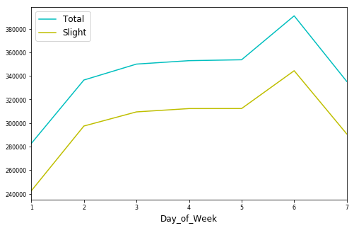

```python
fig, ax = plt.subplots(figsize=(8,5))
csvData.groupby(['Day_of_Week']).sum()['Total Casualities'].plot(ax=ax,c='c',label='Total')
csvData.groupby(['Day_of_Week']).sum()['Slight'].plot(ax=ax,c='y',label='Slight')
plt.legend()
```

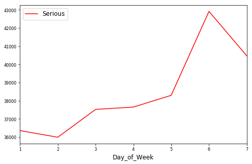

```python
fig, ax = plt.subplots(figsize=(8,5))
csvData.groupby(['Day_of_Week']).sum()['Serious'].plot(ax=ax,c='r',label='Serious')
plt.legend()
```

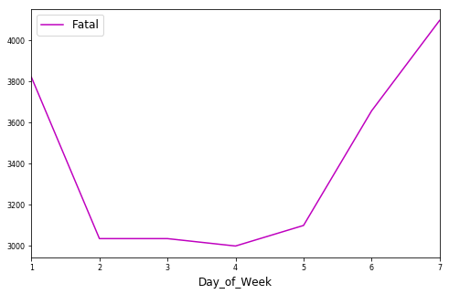

```python
fig, ax = plt.subplots(figsize=(8,5))
csvData.groupby(['Day_of_Week']).sum()['Fatal'].plot(ax=ax,c='m',label='Fatal')
plt.legend()
```

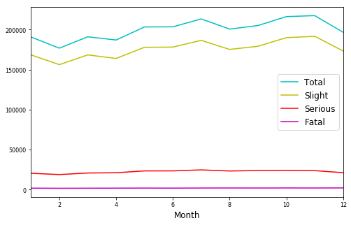

```python
fig, ax = plt.subplots(figsize=(8,5))
csvData.groupby(['Month']).sum()['Total Casualities'].plot(ax=ax,c='c',label='Total')
csvData.groupby(['Month']).sum()['Slight'].plot(ax=ax,c='y',label='Slight')
csvData.groupby(['Month']).sum()['Serious'].plot(ax=ax,c='r',label='Serious')
csvData.groupby(['Month']).sum()['Fatal'].plot(ax=ax,c='m',label='Fatal')
plt.legend()
```

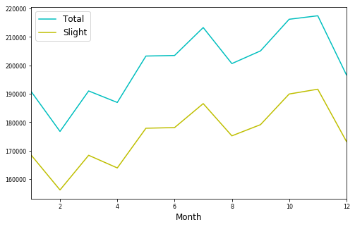

```python
fig, ax = plt.subplots(figsize=(8,5))
csvData.groupby(['Month']).sum()['Total Casualities'].plot(ax=ax,c='c',label='Total')
csvData.groupby(['Month']).sum()['Slight'].plot(ax=ax,c='y',label='Slight')
plt.legend()
```

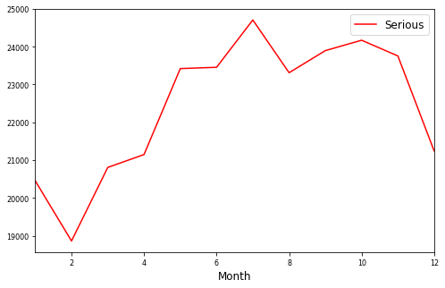

```python
fig, ax = plt.subplots(figsize=(8,5))
csvData.groupby(['Month']).sum()['Serious'].plot(ax=ax,c='r',label='Serious')
plt.legend()
```

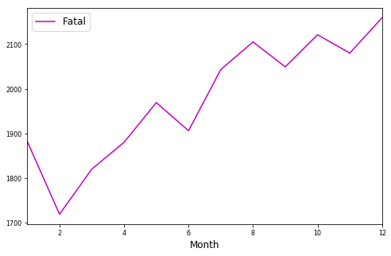

```python
fig, ax = plt.subplots(figsize=(8,5))
csvData.groupby(['Month']).sum()['Fatal'].plot(ax=ax,c='m',label='Fatal')
plt.legend()
```

### Variable Association

#### Correlation

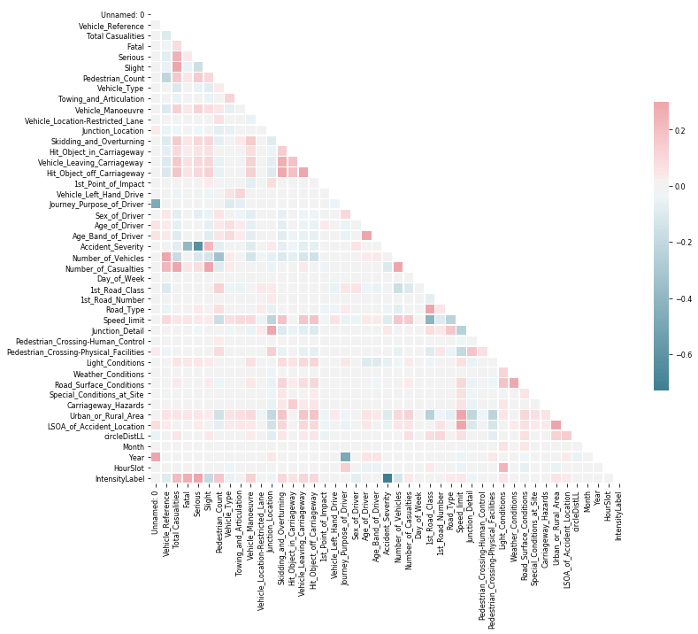

```python
plt.figure(figsize=(12,12))
corr = csvData.corr()
cmap = sns.diverging_palette(220, 10, as_cmap=True)
mask = np.zeros_like(corr, dtype=np.bool)
mask[np.triu_indices_from(mask)] = True
sns.heatmap(corr, mask=mask, cmap=cmap, vmax=.3, center=0,square=True, linewidths=.5, cbar_kws={"shrink": .5})
```

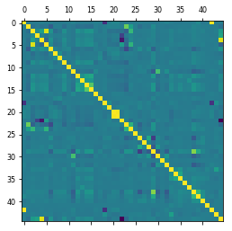

```python
plt.figure(figsize=(20,20))
dataCorrelation = pd.DataFrame(csvData.corr())
plt.matshow(csvData.corr())
```

```python
def colorPandasDF_redOrGreen(val):
    color = 'red' if val < 0.5 else 'green'
    return 'color: %s' % color
dataCorrelation.style.applymap(colorPandasDF_redOrGreen)
```

|  | Unnamed: 0 | Vehicle_Reference | Total Casualities | Fatal | Serious | Slight | Pedestrian_Count | Vehicle_Type | Towing_and_Articulation | Vehicle_Manoeuvre | Vehicle_Location-Restricted_Lane | Junction_Location | Skidding_and_Overturning | Hit_Object_in_Carriageway | Vehicle_Leaving_Carriageway | Hit_Object_off_Carriageway | 1st_Point_of_Impact | Vehicle_Left_Hand_Drive | Journey_Purpose_of_Driver | Sex_of_Driver | Age_of_Driver | Age_Band_of_Driver | Accident_Severity | Number_of_Vehicles | Number_of_Casualties | Day_of_Week | 1st_Road_Class | 1st_Road_Number | Road_Type | … |
| --- | --- | --- | --- | --- | --- | --- | --- | --- | --- | --- | --- | --- | --- | --- | --- | --- | --- | --- | --- | --- | --- | --- | --- | --- | --- | --- | --- | --- | --- | --- |
| Unnamed: 0 | 1 | -0.00153946 | -0.00762042 | -0.00796084 | 0.0122607 | -0.0118311 | 0.002111 | -0.00701728 | -0.00320443 | -0.00977687 | 0.00513809 | 0.0305115 | -0.0202963 | -0.00148044 | -0.0121356 | -0.013847 | 0.0197817 | 0.00101292 | -0.475976 | 0.0175596 | 0.0610511 | 0.0616783 | -0.0152717 | -0.00273383 | -0.00742787 | -0.00275099 | 0.0019292 | -0.00360991 | -0.000780524 | … |
| Vehicle_Reference | -0.00153946 | 1 | -0.0905577 | -0.0323955 | -0.0770726 | -0.0568046 | -0.212572 | 0.000210498 | 0.00117778 | -0.102136 | -0.00783588 | -0.0453163 | -0.0960828 | -0.0675525 | -0.0998111 | -0.10765 | 0.00968629 | -0.0134973 | 0.00872144 | 0.0418178 | 0.0277582 | 0.0382019 | 0.00410693 | 0.610602 | 0.231114 | 0.00125414 | -0.100222 | -0.0178316 | -0.0452547 | … |
| Total Casualities | -0.00762042 | -0.0905577 | 1 | 0.0880852 | 0.250072 | 0.908096 | 0.161691 | -0.104108 | -0.0512652 | 0.131629 | 0.00334143 | -0.0303001 | 0.149633 | 0.0919129 | 0.157447 | 0.172367 | 0.0252016 | -0.0375076 | 0.0233487 | -0.0785833 | -0.0589011 | -0.0864992 | -0.0786233 | -0.181928 | 0.424089 | -0.000587133 | 0.00573136 | 0.00726373 | 0.0200625 | … |
| Fatal | -0.00796084 | -0.0323955 | 0.0880852 | 1 | 0.0355596 | -0.0497794 | 0.0441003 | -0.0011825 | 0.00125115 | 0.0426259 | 0.00348999 | -0.0286907 | 0.0521564 | 0.0275182 | 0.0664984 | 0.0592723 | -0.00486987 | 0.000259154 | 0.0120873 | -0.0294323 | 0.0115815 | 0.00697265 | -0.381168 | -0.024885 | 0.0497011 | -0.000997465 | -0.0190494 | 0.000359737 | 0.0073972 | … |
| Serious | 0.0122607 | -0.0770726 | 0.250072 | 0.0355596 | 1 | -0.159979 | 0.14813 | -0.0504373 | -0.010588 | 0.120039 | 0.0105343 | -0.0306781 | 0.0990503 | 0.0552764 | 0.102079 | 0.0972528 | -0.0172957 | -0.00989554 | 0.0128597 | -0.0631463 | -0.00388834 | -0.0152546 | -0.623921 | -0.111407 | 0.0790953 | -0.00196052 | 0.0134008 | 0.00461339 | 0.0356227 | … |
| Slight | -0.0118311 | -0.0568046 | 0.908096 | -0.0497794 | -0.159979 | 1 | 0.0988219 | -0.0855087 | -0.0481932 | 0.0798326 | -0.00135264 | -0.0147617 | 0.105666 | 0.06776 | 0.110612 | 0.128747 | 0.0334736 | -0.0342945 | 0.0170611 | -0.0506635 | -0.0600437 | -0.0829975 | 0.223849 | -0.137004 | 0.39465 | 0.00033079 | 0.00273274 | 0.00548146 | 0.00493247 | … |
| Pedestrian_Count | 0.002111 | -0.212572 | 0.161691 | 0.0441003 | 0.14813 | 0.0988219 | 1 | 0.0275615 | -0.0111032 | 0.0468382 | 0.0666625 | -0.0713591 | -0.0649855 | -0.0213727 | -0.0547875 | -0.0568386 | 0.0171324 | -0.0108395 | -0.00941193 | 0.0529049 | 0.0379388 | 0.0473468 | -0.0810182 | -0.334699 | -0.0869198 | 0.0132472 | 0.126695 | -0.00135139 | 0.0761385 | … |
| Vehicle_Type | -0.00701728 | 0.000210498 | -0.104108 | -0.0011825 | -0.0504373 | -0.0855087 | 0.0275615 | 1 | 0.112373 | -0.0585483 | 0.00238334 | -0.0549208 | 0.00344404 | -0.0134029 | -0.000489981 | 0.00347356 | -0.00812609 | 0.0614153 | -0.0918108 | 0.022573 | 0.0770914 | 0.0915272 | 0.00412779 | 0.0281263 | 0.0300597 | 0.00254806 | -0.0428152 | -0.0121674 | -0.0221064 | … |
| Towing_and_Articulation | -0.00320443 | 0.00117778 | -0.0512652 | 0.00125115 | -0.010588 | -0.0481932 | -0.0111032 | 0.112373 | 1 | 0.00960836 | 0.00235386 | -0.0294492 | 0.0371719 | -0.00644926 | -0.00229955 | 0.000393227 | 0.0134469 | 0.107142 | -0.0678432 | -0.0346363 | 0.0300682 | 0.0314337 | -0.0210373 | 0.0132157 | 0.00218538 | -0.00216649 | -0.052716 | -0.0133924 | -0.028569 | … |
| Vehicle_Manoeuvre | -0.00977687 | -0.102136 | 0.131629 | 0.0426259 | 0.120039 | 0.0798326 | 0.0468382 | -0.0585483 | 0.00960836 | 1 | -0.047136 | 0.0169311 | 0.147639 | 0.0816252 | 0.12419 | 0.133049 | -0.0809663 | -0.00142448 | 0.0157192 | -0.0782106 | -0.0591727 | -0.0725928 | -0.0875954 | -0.13779 | 0.0080124 | -0.00766158 | -0.00567436 | 0.00489454 | 0.00556839 | … |
| Vehicle_Location-Restricted_Lane | 0.00513809 | -0.00783588 | 0.00334143 | 0.00348999 | 0.0105343 | -0.00135264 | 0.0666625 | 0.00238334 | 0.00235386 | -0.047136 | 1 | -0.00913342 | -0.0113309 | 0.0195747 | 0.00550854 | 0.00727686 | 0.00215672 | 0.000553411 | 0.000872219 | 0.0109652 | -0.0115856 | -0.0158851 | -0.0107171 | -0.0306811 | -0.027467 | 0.000791782 | 0.0366916 | 0.00143235 | 0.0296532 | … |
| Junction_Location | 0.0305115 | -0.0453163 | -0.0303001 | -0.0286907 | -0.0306781 | -0.0147617 | -0.0713591 | -0.0549208 | -0.0294492 | 0.0169311 | -0.00913342 | 1 | -0.0898882 | -0.0425653 | -0.0707289 | -0.0901704 | 0.0820496 | -0.0118919 | -0.00410873 | -0.0286301 | 0.00632401 | 0.00499082 | 0.0371451 | -0.0623684 | -0.0454139 | 0.000398741 | 0.0365553 | 0.0347892 | -0.0584317 | … |
| Skidding_and_Overturning | -0.0202963 | -0.0960828 | 0.149633 | 0.0521564 | 0.0990503 | 0.105666 | -0.0649855 | 0.00344404 | 0.0371719 | 0.147639 | -0.0113309 | -0.0898882 | 1 | 0.146643 | 0.2609 | 0.29247 | -0.000346526 | -0.00458219 | 0.00407747 | -0.0598288 | -0.0723791 | -0.0848483 | -0.0666428 | -0.100821 | 0.0252432 | -0.00745311 | -0.0292698 | -0.00242334 | -0.00563013 | … |
| Hit_Object_in_Carriageway | -0.00148044 | -0.0675525 | 0.0919129 | 0.0275182 | 0.0552764 | 0.06776 | -0.0213727 | -0.0134029 | -0.00644926 | 0.0816252 | 0.0195747 | -0.0425653 | 0.146643 | 1 | 0.18146 | 0.190127 | -0.000364907 | -0.00631124 | 0.0142717 | -0.0245849 | -0.0287211 | -0.0344971 | -0.0320474 | -0.0679926 | -0.00293712 | -0.00531941 | 0.0170552 | -0.00144601 | -0.00457729 | … |
| Vehicle_Leaving_Carriageway | -0.0121356 | -0.0998111 | 0.157447 | 0.0664984 | 0.102079 | 0.110612 | -0.0547875 | -0.000489981 | -0.00229955 | 0.12419 | 0.00550854 | -0.0707289 | 0.2609 | 0.18146 | 1 | 0.545183 | 0.0114477 | -0.00611745 | 0.0187921 | -0.0406237 | -0.0448666 | -0.0561904 | -0.0787277 | -0.120706 | 0.037361 | -0.0069408 | -0.0196872 | 0.00337642 | 0.0149963 | … |
| Hit_Object_off_Carriageway | -0.013847 | -0.10765 | 0.172367 | 0.0592723 | 0.0972528 | 0.128747 | -0.0568386 | 0.00347356 | 0.000393227 | 0.133049 | 0.00727686 | -0.0901704 | 0.29247 | 0.190127 | 0.545183 | 1 | 0.00801231 | -0.00635714 | 0.0204563 | -0.0350515 | -0.0462728 | -0.0580503 | -0.0647409 | -0.147235 | 0.0251042 | -0.00788845 | -0.0252848 | -0.00204874 | 0.00325092 | … |
| 1st_Point_of_Impact | 0.0197817 | 0.00968629 | 0.0252016 | -0.00486987 | -0.0172957 | 0.0334736 | 0.0171324 | -0.00812609 | 0.0134469 | -0.0809663 | 0.00215672 | 0.0820496 | -0.000346526 | -0.000364907 | 0.0114477 | 0.00801231 | 1 | 0.0107668 | -0.00774172 | -0.0140187 | 0.0265474 | 0.0227126 | 0.0189484 | -0.0225608 | -0.039055 | -0.00210712 | -0.00838668 | -0.00682982 | -0.034375 | … |
| Vehicle_Left_Hand_Drive | 0.00101292 | -0.0134973 | -0.0375076 | 0.000259154 | -0.00989554 | -0.0342945 | -0.0108395 | 0.0614153 | 0.107142 | -0.00142448 | 0.000553411 | -0.0118919 | -0.00458219 | -0.00631124 | -0.00611745 | -0.00635714 | 0.0107668 | 1 | -0.0395269 | -0.0214698 | 0.00483359 | 0.00722786 | 0.000903738 | 0.00528614 | 0.000143558 | -0.00162532 | -0.0501318 | -0.0139016 | -0.040953 | … |
| Journey_Purpose_of_Driver | -0.475976 | 0.00872144 | 0.0233487 | 0.0120873 | 0.0128597 | 0.0170611 | -0.00941193 | -0.0918108 | -0.0678432 | 0.0157192 | 0.000872219 | -0.00410873 | 0.00407747 | 0.0142717 | 0.0187921 | 0.0204563 | -0.00774172 | -0.0395269 | 1 | 0.097388 | -0.0426137 | -0.0472681 | 0.00243153 | 0.00777743 | 0.0212197 | 0.00705639 | 0.0441209 | 0.00214317 | 0.0342182 | … |
| Sex_of_Driver | 0.0175596 | 0.0418178 | -0.0785833 | -0.0294323 | -0.0631463 | -0.0506635 | 0.0529049 | 0.022573 | -0.0346363 | -0.0782106 | 0.0109652 | -0.0286301 | -0.0598288 | -0.0245849 | -0.0406237 | -0.0350515 | -0.0140187 | -0.0214698 | 0.097388 | 1 | -0.0278171 | 0.0155429 | 0.0526726 | 0.024617 | -0.023561 | -0.00110771 | 0.0580397 | 0.00449015 | 0.0163603 | … |
| Age_of_Driver | 0.0610511 | 0.0277582 | -0.0589011 | 0.0115815 | -0.00388834 | -0.0600437 | 0.0379388 | 0.0770914 | 0.0300682 | -0.0591727 | -0.0115856 | 0.00632401 | -0.0723791 | -0.0287211 | -0.0448666 | -0.0462728 | 0.0265474 | 0.00483359 | -0.0426137 | -0.0278171 | 1 | 0.973517 | -0.0290991 | 0.0280684 | 0.00808815 | -0.000803405 | -0.0409198 | -0.00251587 | -0.0118648 | … |
| Age_Band_of_Driver | 0.0616783 | 0.0382019 | -0.0864992 | 0.00697265 | -0.0152546 | -0.0829975 | 0.0473468 | 0.0915272 | 0.0314337 | -0.0725928 | -0.0158851 | 0.00499082 | -0.0848483 | -0.0344971 | -0.0561904 | -0.0580503 | 0.0227126 | 0.00722786 | -0.0472681 | 0.0155429 | 0.973517 | 1 | -0.0220107 | 0.0347885 | 0.00302596 | -0.000721783 | -0.0476884 | -0.00484589 | -0.0168028 | … |
| Accident_Severity | -0.0152717 | 0.00410693 | -0.0786233 | -0.381168 | -0.623921 | 0.223849 | -0.0810182 | 0.00412779 | -0.0210373 | -0.0875954 | -0.0107171 | 0.0371451 | -0.0666428 | -0.0320474 | -0.0787277 | -0.0647409 | 0.0189484 | 0.000903738 | 0.00243153 | 0.0526726 | -0.0290991 | -0.0220107 | 1 | 0.00699454 | -0.0995604 | 0.0043148 | 0.0113496 | -0.00300383 | -0.0398783 | … |
| Number_of_Vehicles | -0.00273383 | 0.610602 | -0.181928 | -0.024885 | -0.111407 | -0.137004 | -0.334699 | 0.0281263 | 0.0132157 | -0.13779 | -0.0306811 | -0.0623684 | -0.100821 | -0.0679926 | -0.120706 | -0.147235 | -0.0225608 | 0.00528614 | 0.00777743 | 0.024617 | 0.0280684 | 0.0347885 | 0.00699454 | 1 | 0.378507 | 0.0021204 | -0.164257 | -0.0293247 | -0.0741504 | … |
| Number_of_Casualties | -0.00742787 | 0.231114 | 0.424089 | 0.0497011 | 0.0790953 | 0.39465 | -0.0869198 | 0.0300597 | 0.00218538 | 0.0080124 | -0.027467 | -0.0454139 | 0.0252432 | -0.00293712 | 0.037361 | 0.0251042 | -0.039055 | 0.000143558 | 0.0212197 | -0.023561 | 0.00808815 | 0.00302596 | -0.0995604 | 0.378507 | 1 | 0.00172424 | -0.0989502 | -0.00297154 | -0.0220626 | … |
| Day_of_Week | -0.00275099 | 0.00125414 | -0.000587133 | -0.000997465 | -0.00196052 | 0.00033079 | 0.0132472 | 0.00254806 | -0.00216649 | -0.00766158 | 0.000791782 | 0.000398741 | -0.00745311 | -0.00531941 | -0.0069408 | -0.00788845 | -0.00210712 | -0.00162532 | 0.00705639 | -0.00110771 | -0.000803405 | -0.000721783 | 0.0043148 | 0.0021204 | 0.00172424 | 1 | 0.00464243 | 0.00255365 | 0.00488211 | … |
| 1st_Road_Class | 0.0019292 | -0.100222 | 0.00573136 | -0.0190494 | 0.0134008 | 0.00273274 | 0.126695 | -0.0428152 | -0.052716 | -0.00567436 | 0.0366916 | 0.0365553 | -0.0292698 | 0.0170552 | -0.0196872 | -0.0252848 | -0.00838668 | -0.0501318 | 0.0441209 | 0.0580397 | -0.0409198 | -0.0476884 | 0.0113496 | -0.164257 | -0.0989502 | 0.00464243 | 1 | -0.0643941 | 0.310303 | … |
| 1st_Road_Number | -0.00360991 | -0.0178316 | 0.00726373 | 0.000359737 | 0.00461339 | 0.00548146 | -0.00135139 | -0.0121674 | -0.0133924 | 0.00489454 | 0.00143235 | 0.0347892 | -0.00242334 | -0.00144601 | 0.00337642 | -0.00204874 | -0.00682982 | -0.0139016 | 0.00214317 | 0.00449015 | -0.00251587 | -0.00484589 | -0.00300383 | -0.0293247 | -0.00297154 | 0.00255365 | -0.0643941 | 1 | 0.0519476 | … |
| Road_Type | -0.000780524 | -0.0452547 | 0.0200625 | 0.0073972 | 0.0356227 | 0.00493247 | 0.0761385 | -0.0221064 | -0.028569 | 0.00556839 | 0.0296532 | -0.0584317 | -0.00563013 | -0.00457729 | 0.0149963 | 0.00325092 | -0.034375 | -0.040953 | 0.0342182 | 0.0163603 | -0.0118648 | -0.0168028 | -0.0398783 | -0.0741504 | -0.0220626 | 0.00488211 | 0.310303 | 0.0519476 | 1 | … |
| Speed_limit | -0.0233971 | 0.0997682 | 0.0483901 | 0.052699 | 0.0360525 | 0.0280337 | -0.170238 | 0.0753385 | 0.0922951 | 0.0943334 | -0.0443615 | -0.222939 | 0.185535 | 0.00975233 | 0.174324 | 0.184494 | -0.0320628 | 0.0581704 | -0.0465509 | -0.0438399 | 0.0365947 | 0.0293335 | -0.0872888 | 0.163394 | 0.156958 | -0.0121879 | -0.415261 | -0.094504 | -0.233491 | … |
| Junction_Detail | -0.021507 | -0.0169237 | -0.0266302 | -0.0282627 | -0.0336825 | -0.00982989 | -0.0154457 | -0.029929 | -0.0282884 | -0.0467837 | 0.0335419 | 0.488885 | -0.0965046 | -0.052187 | -0.0772735 | -0.0972514 | 0.024877 | -0.0208771 | 0.0175508 | -0.0135376 | 0.00551943 | 0.00406485 | 0.042326 | -0.0277787 | -0.0225569 | 0.00627005 | 0.0801623 | 0.0401392 | 0.16905 | … |
| Pedestrian_Crossing-Human_Control | 0.00455471 | -0.00801148 | 0.00324719 | -0.0022093 | -0.000779827 | 0.00391551 | 0.0285092 | 0.00046524 | -0.00199402 | -0.00523314 | 0.00295814 | 0.00319268 | -0.00722148 | -0.00401808 | -0.00959963 | -0.0100982 | -0.00204815 | -0.00187637 | -0.00807274 | 0.0044002 | 0.00240811 | 0.00224923 | 0.00456247 | -0.0131548 | -0.0038246 | -0.000239414 | 0.00348861 | 0.00791157 | 0.00138443 | … |
| Pedestrian_Crossing-Physical_Facilities | 0.0328589 | -0.0350701 | 0.00301608 | -0.00748695 | -0.00153833 | 0.00465178 | 0.0885556 | -0.014502 | -0.0209973 | -0.0281301 | -0.0057527 | 0.135191 | -0.0575479 | -0.00561308 | -0.0601282 | -0.0626154 | 0.0154647 | -0.0095245 | -0.0248199 | -0.0086038 | -0.00196547 | 0.00234377 | 0.0167734 | -0.0574133 | -0.0267958 | 0.00461073 | -0.0895685 | 0.0459106 | -0.0447619 | … |
| Light_Conditions | 0.00127114 | -0.0192492 | 0.0541322 | 0.0399079 | 0.0484168 | 0.03042 | 0.00326854 | -0.0140266 | -0.00851035 | 0.0668461 | -0.00906179 | -0.0258263 | 0.0837683 | 0.0575537 | 0.0984202 | 0.107548 | -0.0156036 | 0.00118549 | 0.0394741 | -0.0161926 | -0.0940837 | -0.0905828 | -0.0592763 | -0.0315737 | 0.0302553 | 0.00770392 | -0.0344658 | -0.00246103 | -0.00888221 | … |
| Weather_Conditions | -0.019709 | -9.33613e-05 | 0.00449687 | -0.00322798 | -0.0121633 | 0.00999966 | -0.00707932 | 0.0101191 | -0.00250077 | 0.00812798 | 0.00401833 | -0.0338758 | 0.0264786 | 0.00823452 | 0.0166313 | 0.0224552 | -0.0167775 | -0.00243243 | 0.0155237 | 0.0175476 | -0.0183906 | -0.0151833 | 0.0201585 | -0.000164356 | 0.00429266 | -0.0014738 | 0.0134258 | 0.0102004 | 0.00203048 | … |
| Road_Surface_Conditions | -0.0245519 | 0.000957919 | 0.0325077 | 0.00267963 | -0.00144832 | 0.0334803 | -0.0397562 | 0.0107008 | -0.00474453 | 0.0391791 | -0.0148909 | -0.0545056 | 0.112327 | 0.0267991 | 0.0894014 | 0.103652 | -0.0256947 | -0.00456714 | -0.0240048 | -0.00150312 | -0.0282942 | -0.0305994 | 0.00862444 | 0.00168933 | 0.0310954 | -0.00752157 | 0.0111792 | 0.0145717 | 0.0118611 | … |
| Special_Conditions_at_Site | -0.0102205 | 0.00425073 | 0.0119479 | -0.00286596 | 0.00150138 | 0.0119513 | -0.0239758 | 0.012734 | 0.0132466 | 0.0096438 | -0.00695603 | -0.0401789 | 0.0441441 | 0.013686 | 0.0222598 | 0.0291921 | -0.00630836 | 0.00809764 | -0.0124429 | -0.0091501 | 0.000776539 | -0.0006544 | 0.00180827 | 0.00699267 | 0.0162996 | -0.00214076 | -0.0220893 | -0.00463145 | -0.00981182 | … |
| Carriageway_Hazards | -0.00437216 | -0.0020059 | 0.0211594 | 0.0011839 | 0.00554479 | 0.0191957 | -0.00665291 | 0.00430867 | 0.0025158 | 0.0198984 | -0.00117788 | -0.0559241 | 0.039939 | 0.145154 | 0.0360423 | 0.0426434 | -0.022799 | -0.00247272 | -0.0041972 | -0.00751934 | -0.00809596 | -0.00925 | -0.00495217 | -0.00331043 | 0.012342 | -0.00353832 | -0.0111833 | -0.00338173 | 0.00437225 | … |
| Urban_or_Rural_Area | 0.010376 | 0.0594415 | 0.0517647 | 0.0480744 | 0.0470819 | 0.0275271 | -0.149866 | 0.0620303 | 0.0776485 | 0.0942806 | -0.0359716 | -0.200995 | 0.17761 | 0.014669 | 0.172797 | 0.176556 | -0.0398343 | 0.035194 | -0.0404809 | -0.02567 | 0.0515385 | 0.0384594 | -0.0929486 | 0.0974077 | 0.123482 | -0.0135794 | -0.244385 | -0.0393753 | -0.0671523 | … |
| LSOA_of_Accident_Location | 0.0815646 | 0.0287711 | 0.0213327 | 0.021939 | 0.0289371 | 0.00715859 | -0.066001 | 0.0299294 | 0.0420782 | 0.0351026 | 0.0177741 | -0.149245 | 0.103845 | -0.00141927 | 0.0959225 | 0.0927123 | -0.0385995 | 0.0142454 | -0.0503647 | 0.0240361 | 0.0386984 | 0.0179324 | -0.0526495 | 0.0469483 | 0.0514598 | -0.00173753 | -0.00169831 | 0.0574687 | -0.0161551 | … |
| circleDistLL | -0.0468731 | 0.00220903 | 0.0451449 | 0.0104513 | 0.0161778 | 0.0381759 | -0.000434132 | 0.0242195 | 0.0167128 | 0.0266448 | -0.000809354 | -0.0841837 | 0.0456798 | -0.00716194 | 0.0366259 | 0.0488678 | -0.0434696 | -0.00986203 | -0.0149884 | 0.0175553 | 0.0165988 | 0.00251604 | -0.0213649 | 0.00365397 | 0.0675494 | 0.00360412 | 0.080955 | 0.0988226 | 0.0173013 | … |
| Month | -0.00101212 | 0.00251141 | -0.000705816 | 0.00135845 | 0.00166022 | -0.00157382 | -0.00165921 | -0.00270676 | 0.00083492 | 0.00109607 | 0.00158214 | -0.00172323 | -0.00037403 | -0.00123384 | -0.00422946 | -0.00530282 | 0.000344796 | 0.00240043 | 0.0033605 | 0.00138164 | 0.00407576 | 0.00357508 | -0.00379841 | 0.00421709 | 0.00257803 | 0.00156739 | -0.00381319 | -0.00310185 | -0.00499187 | … |
| Year | 0.995255 | -0.00366455 | -0.00852867 | -0.00894828 | 0.0115001 | -0.012323 | 0.00650893 | -0.00847073 | -0.00478341 | -0.0114277 | 0.00354066 | 0.0419057 | -0.0262941 | -0.000417611 | -0.0171527 | -0.0191432 | 0.02297 | 0.000504576 | -0.479112 | 0.0148486 | 0.0593764 | 0.0615679 | -0.013291 | -0.00621446 | -0.0103277 | -0.00269801 | -0.00068782 | -0.00703331 | 0.00171304 | … |
| HourSlot | -0.0100575 | -0.00756848 | 0.0138059 | -0.00652661 | 0.00423648 | 0.013184 | 0.0187118 | -0.0383438 | -0.0184866 | 0.00818634 | -0.00538578 | 0.020776 | -0.022023 | -0.0161196 | -0.0231527 | -0.028925 | 0.00094636 | -0.00449315 | 0.137687 | -0.00086649 | -0.0487904 | -0.0537321 | -0.00261304 | -0.0124391 | 0.0223597 | 0.025326 | 0.0376842 | 0.00701471 | 0.021066 | … |
| IntensityLabel | 0.0130788 | -0.0866135 | 0.214024 | 0.265636 | 0.917499 | -0.191703 | 0.163511 | -0.0546238 | -0.0101345 | 0.13097 | 0.0123464 | -0.0352528 | 0.104373 | 0.0579516 | 0.107718 | 0.100945 | -0.0184886 | -0.0104421 | 0.0104292 | -0.0709436 | 0.00232259 | -0.00990432 | -0.729495 | -0.122701 | 0.0384938 | -0.00231117 | 0.0126385 | 0.00529801 | 0.0383307 | … |

#### One-way ANOVA

##### Road speed limit

```python
csvData["Speed_limit"].unique()
```

```
array([ 30.,  40.,  50.,  20.,  60.,  70.,  10.,  15.,   0.])
```

```python
speed10 = csvData[csvData["Speed_limit"] == 30.0]["Total Casualities"]
speed30 = csvData[csvData["Speed_limit"] == 30.0]["Total Casualities"]
speed40 = csvData[csvData["Speed_limit"] == 30.0]["Total Casualities"]
speed60 = csvData[csvData["Speed_limit"] == 60.0]["Total Casualities"]
speed70 = csvData[csvData["Speed_limit"] == 70.0]["Total Casualities"]
```

```python
_, p_val = stats.f_oneway(speed10, speed30, speed40, speed60, speed70)
print('P-value = ',p_val)
```

```
P-value =  0.0
```

If p-value > 0.05, it may be claimed with high confidence that mean of the above 5 groups are not significantly different. Here p-value = 0 and therefore, null hypothesis is rejected and we may to accept that the groups are different. It may however be noted that With large sample size, any differences can be significant enough leading to a very small P-value. So, the test is repeated with a smaller sample size.Going forward, smaller dataset will be used to quantify variable association with one-way ANOVA

```python
csvData2016 = pd.read_csv("Exploratory2016.csv")
#print(list(csvData2016.columns))
speed10 = csvData2016[csvData2016["Speed_limit"] == 30.0]["Total Casualities"]
speed30 = csvData2016[csvData2016["Speed_limit"] == 30.0]["Total Casualities"]
speed40 = csvData2016[csvData2016["Speed_limit"] == 30.0]["Total Casualities"]
speed60 = csvData2016[csvData2016["Speed_limit"] == 60.0]["Total Casualities"]
speed70 = csvData2016[csvData2016["Speed_limit"] == 70.0]["Total Casualities"]
_, p_val = stats.f_oneway(speed10, speed30, speed40, speed60, speed70)
print('P-value for Speed limit = ',p_val)
del speed10, speed30, speed40, speed60, speed70
```

```
P-value for Speed limit =  1.7061709965e-210
```

Here again, p-value is too small leading us to reject the null hypothesis again. So, the groups appear to be different and it may be confidently said that the accidents are considerably different in the various speed limits.

##### Driver Gender

```python
csvData2016["Sex_of_Driver"].unique()
```

```
array([ 1.,  2.,  3.])
```

```python
male = csvData2016[csvData2016["Sex_of_Driver"] == 1.0]["Total Casualities"]
female = csvData2016[csvData2016["Sex_of_Driver"] == 2.0]["Total Casualities"]
_, p_val = stats.f_oneway(male,female)
print('P-value for driver gender = ',p_val)
del male,female
```

```
P-value for driver gender =  6.92798971732e-132
```

##### Road type

```python
csvData2016["1st_Road_Class"].unique()
```

```
array([3, 5, 4, 6, 1, 2], dtype=int64)
```

```python
road1 = csvData2016[csvData2016["1st_Road_Class"] == 1]["Total Casualities"]
road2 = csvData2016[csvData2016["1st_Road_Class"] == 2]["Total Casualities"]
road3 = csvData2016[csvData2016["1st_Road_Class"] == 3]["Total Casualities"]
road4 = csvData2016[csvData2016["1st_Road_Class"] == 4]["Total Casualities"]
road5 = csvData2016[csvData2016["1st_Road_Class"] == 5]["Total Casualities"]
_, p_val = stats.f_oneway(road1, road2, road3, road4, road5)
print('P-value for driver gender = ',p_val)
del road1, road2, road3, road4, road5
```

```
P-value for driver gender =  1.8790888911e-09
```

Differnt road categories i.e. Motorways, A/B/C roads etc are different in terms of casualty count

##### Weather condition

```python
csvData2016["Weather_Conditions"].unique()
```

```
array([ 1.,  2.,  7.,  8.,  9.,  4.,  5.,  3.,  6.])
```

```python
dry = csvData2016[csvData2016["Weather_Conditions"] == 1.0]["Total Casualities"]
rain = csvData2016[csvData2016["Weather_Conditions"] == 2.0]["Total Casualities"]
snow = csvData2016[csvData2016["Weather_Conditions"] == 3.0]["Total Casualities"]
dryNwindy = csvData2016[csvData2016["Weather_Conditions"] == 4.0]["Total Casualities"]
rainNwindy = csvData2016[csvData2016["Weather_Conditions"] == 5.0]["Total Casualities"]
snowNwindy = csvData2016[csvData2016["Weather_Conditions"] == 6.0]["Total Casualities"]
fog = csvData2016[csvData2016["Weather_Conditions"] == 7.0]["Total Casualities"]
_, p_val = stats.f_oneway(dry, rain, snow, dryNwindy, rainNwindy, snowNwindy, fog)
print('P-value for driver gender = ',p_val)
del dry, rain, snow, dryNwindy, rainNwindy, snowNwindy, fog
```

```
P-value for driver gender =  3.65628924646e-25
```

```python
del csvData2016, csvData
```

#### Class label distribution

```python
classDistribution = csvData['IntensityLabel'].value_counts()
print('Class imbalance:')
print(classDistribution)
```

[output not shown]

Future improvements will include: (1) Spatial auto-correlation with Moran's I test. (2) Multi-dimensional scaling of dataset to assess the distance between various categories of class labels to evaluate further data transformation.(3) Combine with other datasets like traffic volume, population by LSOA etc. to derive better insights and class label.